# Mini-Project 01

# Data Visualization Project 01

# Email:ssadeghizadeh8676@floridapoly.edu

# Mini Project:

For this *mini project* I worked on world cup matches dataset, which includes matches during 1930 to 2014 held in different cities between different teams with some main variables which I worked on them mainly such as Home team goals, away team goals, audience also some other variable to be used created for this report such as total goals. Here I listed some *main steps* to start working on this dataset:

**Step 1**: Using the function read_csv() to read and variables are assigned for further use.

**Step 2**: Datasets are checked for any duplicate rows and only distinct rows are kept. After removal of duplicates, the dimensions of both the datasets are checked.

**Step 3**: As some variables are not needed at all in this report, I deleted some of them, for this task, function subset () was used.

**Step 4**: The structure of this dataset is displayed using the str () function.

**Step 5**: using the function Separate () to split the ‘Date’ and ‘Time’ as 2 different columns. then format the separated columns. using head () function to see some first rows of the new table.

**Step6**: Creating 3 new variable by using the mutate function: Home_Sec_Half and Away_Sec_Half, total to find if scores gain in final minutes or not. Also, total goals which helps to find total score after each match.

**Step7**: dataset is checked for missing values and obvious errors (functions colSums() and is.na())

```r
library(tidyverse)
library(dplyr)
WC_Matches<- read_csv("https://raw.githubusercontent.com/reisanar/datasets/master/WorldCupMatches.csv")
WC_Matches
```

```
## # A tibble: 4,572 x 20
##     Year Datetime Stage Stadium City  `Home Team Name` `Home Team Goal…
##    <dbl> <chr>    <chr> <chr>   <chr> <chr>                       <dbl>
##  1  1930 13 Jul … Grou… Pocitos Mont… France                          4
##  2  1930 13 Jul … Grou… Parque… Mont… USA                             3
##  3  1930 14 Jul … Grou… Parque… Mont… Yugoslavia                      2
##  4  1930 14 Jul … Grou… Pocitos Mont… Romania                         3
##  5  1930 15 Jul … Grou… Parque… Mont… Argentina                       1
##  6  1930 16 Jul … Grou… Parque… Mont… Chile                           3
##  7  1930 17 Jul … Grou… Parque… Mont… Yugoslavia                      4
##  8  1930 17 Jul … Grou… Parque… Mont… USA                             3
##  9  1930 18 Jul … Grou… Estadi… Mont… Uruguay                         1
## 10  1930 19 Jul … Grou… Estadi… Mont… Chile                           1
## # … with 4,562 more rows, and 13 more variables: `Away Team Goals` <dbl>, `Away
## #   Team Name` <chr>, `Win conditions` <chr>, Attendance <dbl>, `Half-time Home
## #   Goals` <dbl>, `Half-time Away Goals` <dbl>, Referee <chr>, `Assistant
## #   1` <chr>, `Assistant 2` <chr>, RoundID <dbl>, MatchID <dbl>, `Home Team
## #   Initials` <chr>, `Away Team Initials` <chr>
```

```r
#check for duplicates and subset only distinct rows
WC_Matches_distinct<-WC_Matches%>%distinct()
WC_Matches_distinct
```

```
## # A tibble: 837 x 20
##     Year Datetime Stage Stadium City  `Home Team Name` `Home Team Goal…
##    <dbl> <chr>    <chr> <chr>   <chr> <chr>                       <dbl>
##  1  1930 13 Jul … Grou… Pocitos Mont… France                          4
##  2  1930 13 Jul … Grou… Parque… Mont… USA                             3
##  3  1930 14 Jul … Grou… Parque… Mont… Yugoslavia                      2
##  4  1930 14 Jul … Grou… Pocitos Mont… Romania                         3
##  5  1930 15 Jul … Grou… Parque… Mont… Argentina                       1
##  6  1930 16 Jul … Grou… Parque… Mont… Chile                           3
##  7  1930 17 Jul … Grou… Parque… Mont… Yugoslavia                      4
##  8  1930 17 Jul … Grou… Parque… Mont… USA                             3
##  9  1930 18 Jul … Grou… Estadi… Mont… Uruguay                         1
## 10  1930 19 Jul … Grou… Estadi… Mont… Chile                           1
## # … with 827 more rows, and 13 more variables: `Away Team Goals` <dbl>, `Away
## #   Team Name` <chr>, `Win conditions` <chr>, Attendance <dbl>, `Half-time Home
## #   Goals` <dbl>, `Half-time Away Goals` <dbl>, Referee <chr>, `Assistant
## #   1` <chr>, `Assistant 2` <chr>, RoundID <dbl>, MatchID <dbl>, `Home Team
## #   Initials` <chr>, `Away Team Initials` <chr>
```

```r
#check dimensions
dim(WC_Matches_distinct)
```

```
## [1] 837  20
```

```r
#(deleting unnecessary coloumns in this analysis)
WC_Matches_new <- subset(WC_Matches_distinct[,c(1,2,5,6,7,8,9,10,11,12,13,17,18,19,20)] )
#Viewing the subset
head(WC_Matches_new)
```

```
## # A tibble: 6 x 15
##    Year Datetime City  `Home Team Name` `Home Team Goal… `Away Team Goal…
##   <dbl> <chr>    <chr> <chr>                       <dbl>            <dbl>
## 1  1930 13 Jul … Mont… France                          4                1
## 2  1930 13 Jul … Mont… USA                             3                0
## 3  1930 14 Jul … Mont… Yugoslavia                      2                1
## 4  1930 14 Jul … Mont… Romania                         3                1
## 5  1930 15 Jul … Mont… Argentina                       1                0
## 6  1930 16 Jul … Mont… Chile                           3                0
## # … with 9 more variables: `Away Team Name` <chr>, `Win conditions` <chr>,
## #   Attendance <dbl>, `Half-time Home Goals` <dbl>, `Half-time Away
## #   Goals` <dbl>, RoundID <dbl>, MatchID <dbl>, `Home Team Initials` <chr>,
## #   `Away Team Initials` <chr>
```

```r
str(str(WC_Matches_new))
```

```
## tibble [837 × 15] (S3: tbl_df/tbl/data.frame)
##  $ Year                : num [1:837] 1930 1930 1930 1930 1930 1930 1930 1930 1930 1930 ...
##  $ Datetime            : chr [1:837] "13 Jul 1930 - 15:00" "13 Jul 1930 - 15:00" "14 Jul 1930 - 12:45" "14 Jul 1930 - 14:50" ...
##  $ City                : chr [1:837] "Montevideo" "Montevideo" "Montevideo" "Montevideo" ...
##  $ Home Team Name      : chr [1:837] "France" "USA" "Yugoslavia" "Romania" ...
##  $ Home Team Goals     : num [1:837] 4 3 2 3 1 3 4 3 1 1 ...
##  $ Away Team Goals     : num [1:837] 1 0 1 1 0 0 0 0 0 0 ...
##  $ Away Team Name      : chr [1:837] "Mexico" "Belgium" "Brazil" "Peru" ...
##  $ Win conditions      : chr [1:837] NA NA NA NA ...
##  $ Attendance          : num [1:837] 4444 18346 24059 2549 23409 ...
##  $ Half-time Home Goals: num [1:837] 3 2 2 1 0 1 0 2 0 0 ...
##  $ Half-time Away Goals: num [1:837] 0 0 0 0 0 0 0 0 0 0 ...
##  $ RoundID             : num [1:837] 201 201 201 201 201 201 201 201 201 201 ...
##  $ MatchID             : num [1:837] 1096 1090 1093 1098 1085 ...
##  $ Home Team Initials  : chr [1:837] "FRA" "USA" "YUG" "ROU" ...
##  $ Away Team Initials  : chr [1:837] "MEX" "BEL" "BRA" "PER" ...
##  NULL
```

```r
library(dplyr)
WC_Matches_new <- WC_Matches_new %>% tidyr::separate(Datetime,into = c("Date", "Time"),sep =" - ")
WC_Matches_new$Date <- as.Date(WC_Matches_new$Date, format = "%d %b %Y")
#Confirming the structure of the 'Date' Column
str(WC_Matches_new$Date)
```

```
##  Date[1:837], format: "1930-07-13" "1930-07-13" "1930-07-14" "1930-07-14" "1930-07-15" ...
```

```r
WC_Matches_new$Time <- hms::parse_hm(WC_Matches_new$Time)
#Confirming the structure of `Time` Column
str(WC_Matches_new$Time)
```

```
##  'hms' num [1:837] 15:00:00 15:00:00 12:45:00 14:50:00 ...
##  - attr(*, "units")= chr "secs"
```

```r
head(WC_Matches_new)
```

```
## # A tibble: 6 x 16
##    Year Date       Time  City  `Home Team Name` `Home Team Goal…
##   <dbl> <date>     <tim> <chr> <chr>                       <dbl>
## 1  1930 1930-07-13 15:00 Mont… France                          4
## 2  1930 1930-07-13 15:00 Mont… USA                             3
## 3  1930 1930-07-14 12:45 Mont… Yugoslavia                      2
## 4  1930 1930-07-14 14:50 Mont… Romania                         3
## 5  1930 1930-07-15 16:00 Mont… Argentina                       1
## 6  1930 1930-07-16 14:45 Mont… Chile                           3
## # … with 10 more variables: `Away Team Goals` <dbl>, `Away Team Name` <chr>,
## #   `Win conditions` <chr>, Attendance <dbl>, `Half-time Home Goals` <dbl>,
## #   `Half-time Away Goals` <dbl>, RoundID <dbl>, MatchID <dbl>, `Home Team
## #   Initials` <chr>, `Away Team Initials` <chr>
```

```r
#Creating 3 new variable by using the mutate function
WC_Matches_new<- mutate(WC_Matches_new,Home_Sec_Half = WC_Matches_new$`Home Team Goals` - WC_Matches_new$`Half-time Home Goals`, Away_Sec_Half= WC_Matches_new$`Away Team Goals`- WC_Matches_new$`Half-time Away Goals`,Total_Goals = WC_Matches_new$`Home Team Goals` + WC_Matches_new$`Away Team Goals`)
#Displaying the dataset
head(WC_Matches_new)
```

```
## # A tibble: 6 x 19
##    Year Date       Time  City  `Home Team Name` `Home Team Goal…
##   <dbl> <date>     <tim> <chr> <chr>                       <dbl>
## 1  1930 1930-07-13 15:00 Mont… France                          4
## 2  1930 1930-07-13 15:00 Mont… USA                             3
## 3  1930 1930-07-14 12:45 Mont… Yugoslavia                      2
## 4  1930 1930-07-14 14:50 Mont… Romania                         3
## 5  1930 1930-07-15 16:00 Mont… Argentina                       1
## 6  1930 1930-07-16 14:45 Mont… Chile                           3
## # … with 13 more variables: `Away Team Goals` <dbl>, `Away Team Name` <chr>,
## #   `Win conditions` <chr>, Attendance <dbl>, `Half-time Home Goals` <dbl>,
## #   `Half-time Away Goals` <dbl>, RoundID <dbl>, MatchID <dbl>, `Home Team
## #   Initials` <chr>, `Away Team Initials` <chr>, Home_Sec_Half <dbl>,
## #   Away_Sec_Half <dbl>, Total_Goals <dbl>
```

```r
#remove spaces from column names
names(WC_Matches_new) <- make.names(names(WC_Matches_new), unique=TRUE)
head(WC_Matches_new)
```

```
## # A tibble: 6 x 19
##    Year Date       Time  City  Home.Team.Name Home.Team.Goals Away.Team.Goals
##   <dbl> <date>     <tim> <chr> <chr>                    <dbl>           <dbl>
## 1  1930 1930-07-13 15:00 Mont… France                       4               1
## 2  1930 1930-07-13 15:00 Mont… USA                          3               0
## 3  1930 1930-07-14 12:45 Mont… Yugoslavia                   2               1
## 4  1930 1930-07-14 14:50 Mont… Romania                      3               1
## 5  1930 1930-07-15 16:00 Mont… Argentina                    1               0
## 6  1930 1930-07-16 14:45 Mont… Chile                        3               0
## # … with 12 more variables: Away.Team.Name <chr>, Win.conditions <chr>,
## #   Attendance <dbl>, Half.time.Home.Goals <dbl>, Half.time.Away.Goals <dbl>,
## #   RoundID <dbl>, MatchID <dbl>, Home.Team.Initials <chr>,
## #   Away.Team.Initials <chr>, Home_Sec_Half <dbl>, Away_Sec_Half <dbl>,
## #   Total_Goals <dbl>
```

```r
#check for missing values
colSums(is.na(WC_Matches_new))
```

```
##                 Year                 Date                 Time
##                    1                    1                    1
##                 City       Home.Team.Name      Home.Team.Goals
##                    1                    1                    1
##      Away.Team.Goals       Away.Team.Name       Win.conditions
##                    1                    1                  780
##           Attendance Half.time.Home.Goals Half.time.Away.Goals
##                    2                    1                    1
##              RoundID              MatchID   Home.Team.Initials
##                    1                    1                    1
##   Away.Team.Initials        Home_Sec_Half        Away_Sec_Half
##                    1                    1                    1
##          Total_Goals
##                    1
```

# Analysis:

## After making data tidy,we start to analyse the data:

- **Audiences Distribution**: After making data tidy, I started analysis of data by drawing a *histogram* of audiences: We can see in the graphs that the data is skewed to the right.
- **Total Goals Distribution**: Checking the distribution of total goals using the *hist () function*. We can see total goals in the graphs are skewed to the right.
- **Boxplot**: Checking *median* and *outliers* for home team goal box variable through boxplot for 3 different variables.

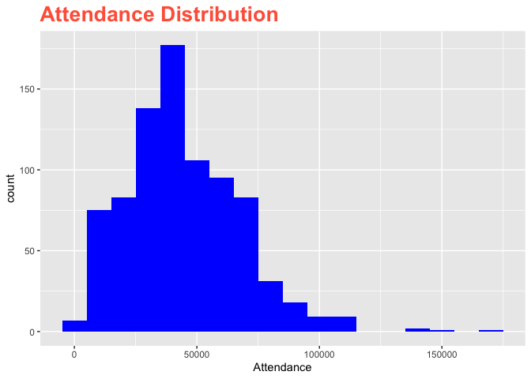

```r
ggplot(data =WC_Matches_new) + geom_histogram(aes(x = Attendance),binwidth = 10000,fill="BLUE")+labs(title="Attendance Distribution")+theme(plot.title = element_text(size = 20, face = "bold",color="tomato"))
```

Checking the distribution of both the variables using the hist() function. We can see in the graphs that the data is *skewed to the right*.

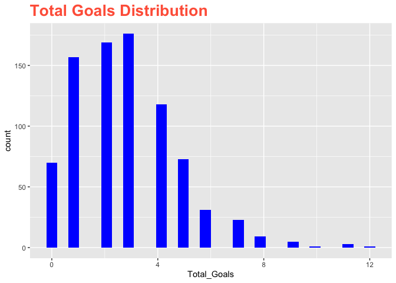

```r
ggplot(data =WC_Matches_new) + geom_histogram(aes(x =Total_Goals),fill="blue")+labs(title="Total Goals Distribution")+theme(plot.title = element_text(size = 20, face = "bold",color="tomato"))
```

Checking the distribution of both the variables using the hist() function. We can see total goals in the graphs are *skewed to the right*.

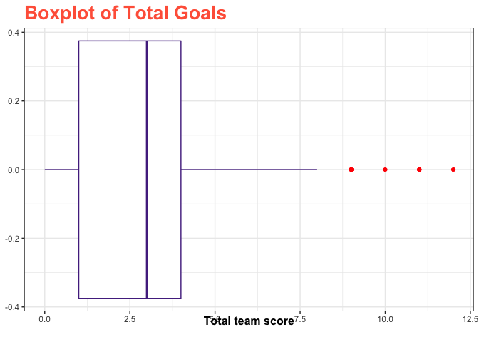

```r
library(ggthemes)
ggplot(WC_Matches_new,aes(Total_Goals))+geom_boxplot(fill = "white", colour = "#532d8e",outlier.colour = "red")+scale_color_brewer()+theme_bw()+labs(title="Boxplot of Total Goals",x="Total team score")+theme(axis.title.x = element_text(vjust = 5,size = 12,face = "bold"))+theme(plot.title = element_text(size = 20, face = "bold",color="tomato"))
```

Checking median and outliers for total box variable through boxplot.the **median** for this variable is around 3 goals and outliers starts from 9 goals.

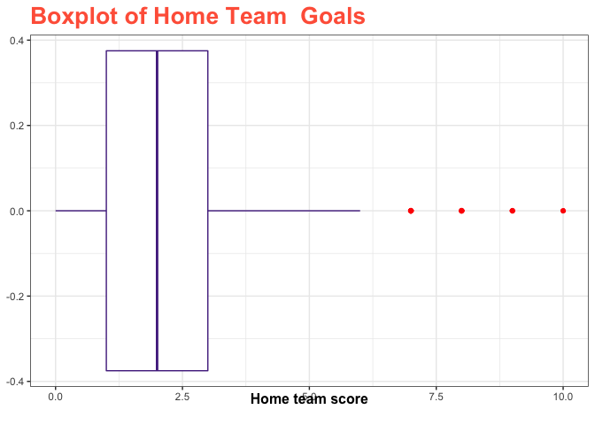

```r
ggplot(WC_Matches_new,aes(Home.Team.Goals))+geom_boxplot(fill = "white", colour = "#532d8e",outlier.colour = "red")+scale_color_brewer()+theme_bw()+labs(title="Boxplot of Home Team  Goals",x="Home team score")+theme(axis.title.x = element_text(vjust = 5,size = 12,face = "bold"))+theme(plot.title = element_text(size = 20, face = "bold",color="tomato"))
```

Checking median and outliers for home team goal box variable through boxplot.the **median** for this variable is 2 goals and outliers starts from 7 goals.

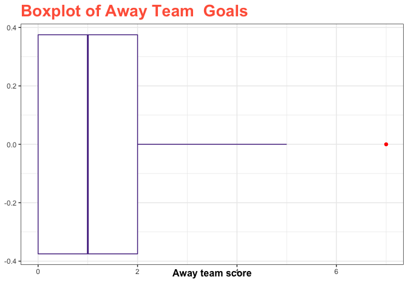

```r
ggplot(WC_Matches_new,aes(Away.Team.Goals))+geom_boxplot(fill = "white", colour = "#532d8e",outlier.colour = "red")+scale_color_brewer()+theme_bw()+labs(title="Boxplot of Away Team  Goals",x="Away team score")+theme(axis.title.x = element_text(vjust = 5,size = 12,face = "bold"))+theme(plot.title = element_text(size = 20, face = "bold",color="tomato"))
```

Checking median and outliers for Away team goal box variable through boxplot.the **median** for this variable is 1 goals and outliers starts from 7 goals.

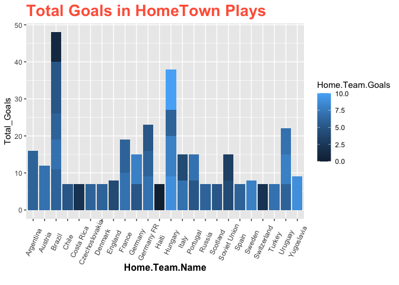

```r
WC_Matches_new%>%
filter(Total_Goals>=7)%>%
ggplot(aes(x =Home.Team.Name,y =Total_Goals,fill=Home.Team.Goals)) + geom_col()+theme(axis.text.x =element_text(angle=65,vjust=0.6))+labs(title = "Total Goals in HomeTown Plays")+theme(axis.title.x = element_text(vjust = 5,size = 12,face = "bold"))+theme(plot.title = element_text(size = 20, face = "bold",color="tomato"))
```

- **Total Goals in Hometown Plays**: Checking number of total goals for matches with higher goals which were played in hometowns, using (geom_col) filling with Home Team Goals and using element _text to have clear presentation to show high numbers in **Brazil** and **Hungary**.

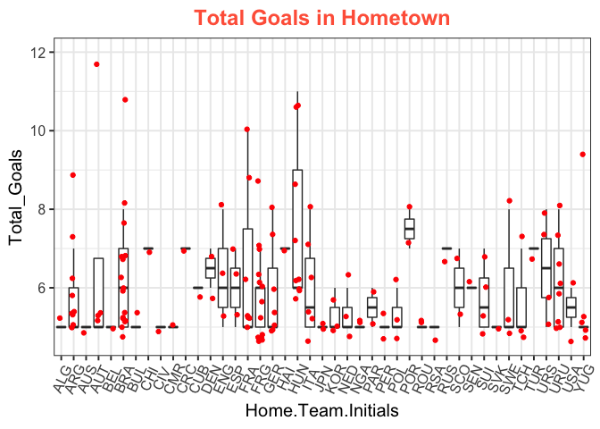

```r
# Remove outliers when overlaying boxplot with original data points
WC_sub <-WC_Matches_new %>%
filter(Total_Goals>4) %>%
mutate(more_goals =ifelse(Total_Goals> 5, Total_Goals, ""))
p <- ggplot(WC_sub, aes(Home.Team.Initials,Total_Goals))
p + geom_boxplot(outlier.shape = NA)+theme_bw(base_size = 15)+theme(axis.text.x =element_text(angle=65,vjust=0.6))+labs(title="Total Goals in Hometown")+theme(plot.title = element_text(size = 18, face = "bold",color = "tomato", hjust = 0.5,lineheight = 1.1))+geom_jitter(color="red",width=0.2)
```

- **Total Goals in Hometown**: to see *median* and *outliers* for every home team matches, in another plot I used *boxplot* and *geom_jitter*.to see the details more obvious.

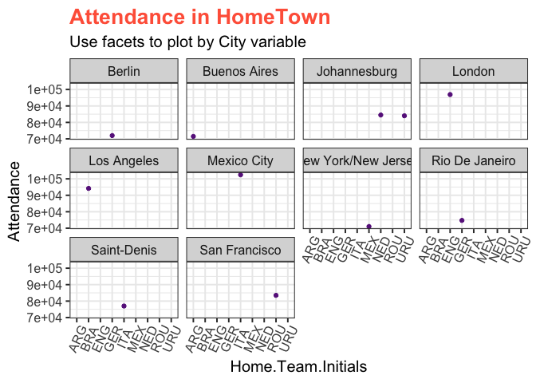

```r
WC_Matches_new %>%
na.omit() %>%
filter(Attendance >70000 & Attendance < 150000) %>%
ggplot(aes(x = Home.Team.Initials, y = Attendance)) +
geom_point(color = "darkorchid4") +
facet_wrap(~ City ) +
labs(title = "Attendance in HomeTown",
subtitle = "Use facets to plot by City variable",y = "Attendance",
x = "Home.Team.Initials") + theme_bw(base_size = 15)+theme(axis.text.x =element_text(angle=65,vjust=0.6))+theme(plot.title = element_text(size = 20, face = "bold",color="tomato"))
```

- **Attendance in Home Town** : to show Drawing number of attendances in home team matches in different cities, attendance in cities like **London** and **Mexico City** and **Los Angeles** were more than other cities for, to be more specific I filtered number of audiences between 70,000 to 150,000 and used the function of facet_wrap to separate cities.

[figure not shown]

```r
WC_sub <-WC_Matches_new  %>%
 filter(Attendance>100000) %>%
 mutate(large_Attendance = ifelse( Attendance> 50000, Total_Goals, ""))
ggplot(data=WC_sub,aes(x =Home.Team.Name,y =Attendance,
fill = Total_Goals)) + geom_col() +
guides(fill = FALSE)+theme_classic()+labs(x = "",title = "Attendance VS.HomeTeamName")+labs(subtitle = "More than 50000 attendance")+theme(plot.title = element_text(size = 20, face = "bold",color = "tomato", hjust = 0.5,lineheight = 1.2),plot.subtitle = element_text(size = 15, face = "bold",hjust = 0.5),plot.caption = element_text(size = 15),
# X axis title
axis.title.x = element_text(vjust = 10,
size = 15),
# Y axis title
axis.title.y = element_text(size = 15),
# X axis text
axis.text.x = element_text(size = 12, angle = 30, vjust = .5), # Y axis text
axis.text.y = element_text(size = 10))
```

```r
WC_Matches_new1<-WC_Matches_new %>%
mutate(winning_team = case_when(Home.Team.Goals > Away.Team.Goals ~ Home.Team.Name,TRUE ~ Away.Team.Name)) %>%
select(1:8, winning_team, everything())
head(WC_Matches_new1)
```

```
## # A tibble: 6 x 20
##    Year Date       Time  City  Home.Team.Name Home.Team.Goals Away.Team.Goals
##   <dbl> <date>     <tim> <chr> <chr>                    <dbl>           <dbl>
## 1  1930 1930-07-13 15:00 Mont… France                       4               1
## 2  1930 1930-07-13 15:00 Mont… USA                          3               0
## 3  1930 1930-07-14 12:45 Mont… Yugoslavia                   2               1
## 4  1930 1930-07-14 14:50 Mont… Romania                      3               1
## 5  1930 1930-07-15 16:00 Mont… Argentina                    1               0
## 6  1930 1930-07-16 14:45 Mont… Chile                        3               0
## # … with 13 more variables: Away.Team.Name <chr>, winning_team <chr>,
## #   Win.conditions <chr>, Attendance <dbl>, Half.time.Home.Goals <dbl>,
## #   Half.time.Away.Goals <dbl>, RoundID <dbl>, MatchID <dbl>,
## #   Home.Team.Initials <chr>, Away.Team.Initials <chr>, Home_Sec_Half <dbl>,
## #   Away_Sec_Half <dbl>, Total_Goals <dbl>
```